# Summarizing Scores In Bioconductor

Rockefeller University, Bioinformatics Resource Centre

http://rockefelleruniversity.github.io/Bioconductor_Introduction/

# Raw Sequence data.

Sequencing data from Illumina sequences machines are often stored in FASTQ format.

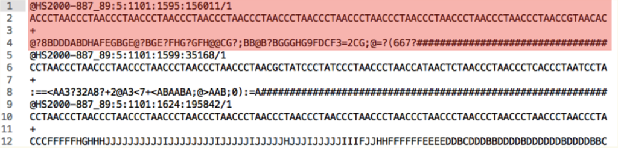

# Summarizing in/over regions.

A common analysis step in the interpretation of high-throughput sequencing experiments is to quantify the abundance of sequence in/over genomic regions.

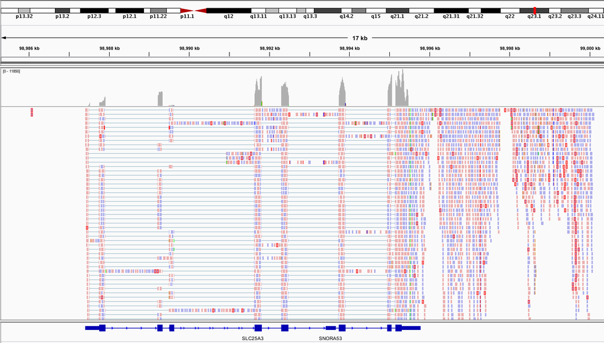

# Summarizing in/over regions.

- **In ChIP-seq** experiments we compare the number of DNA fragments mapping to a genomic locus after an IP for a specific protein or DNA/histone state versus the number of DNA fragments mapping from a background control/input sample.

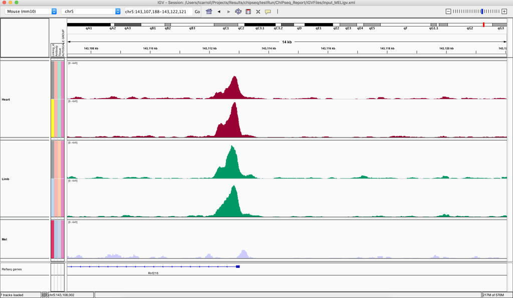

# Summarising alignments over the genome.

We can provide a summarisation of aligned data per base pair using **wig, bedgraph and bigWig** files.

[figure not shown]

# Summarising alignments in Bioconductor.

We will use two main functions ,available on all systems, to allows us to summarise our aligned data over the genome and within regions.

These are the **coverage()** and **summarizeOverlaps()** functions from **GenomicsAlignments** package.

- **coverage()** - To create per base pair signal/alignments scores across genome i.e. bigWigs.
- **summarizeOverlaps()** - To create counts of signal/alignments within genomic regions.

We also look a popular **featureCounts** method available in the **Rsubread** package available on Mac and linux.

# The Data

In this session we will work with aligned data as BAM files.

I have provided BAM files we saw in our last session as our test data from today.

This can be found in **Data/liver.bodyMap.bam** and **Data/heart.bodyMap.bam**.

- **Data/liver.bodyMap.bam**
- **Data/heart.bodyMap.bam**

# GenomicAlignments packages.

To make use of a GenomicsAlignments package we must first load the library.

```r
library(GenomicAlignments)
```

# Coverage

The **coverage()** function can accept a Bam file path and will return an [Rlelist](https://rockefelleruniversity.github.io/Bioconductor_Introduction/r_course/presentations/slides/GenomicScores_In_Bioconductor.html#22) of the number of reads at every base pair.

We should always work with sorted and indexed BAM files so we will perform these steps first.

```r
sortedHeart <- sortBam("Data/heart.bodyMap.bam","Heart")
indexBam(sortedHeart)
```

```
##       Heart.bam
## "Heart.bam.bai"
```

# Coverage as RLElist

As we have seen, [Rlelist](https://rockefelleruniversity.github.io/Bioconductor_Introduction/r_course/presentations/slides/GenomicScores_In_Bioconductor.html#22) objects contain compressed vectors carrying the scores, here number of alignments, for every base pair in the genome.

Here we see scores only on chromosome 12 around the gene we have been reviewing, SLC25A3.

```r
heartCoverage
```

```
## RleList of length 2
## $chr11
## integer-Rle of length 135006516 with 1 run
##   Lengths: 135006516
##   Values :         0
##
## $chr12
## integer-Rle of length 133851895 with 11709 runs
##   Lengths: 98000125       75     1733 ...       45       50 33855282
##   Values :        0        1        0 ...        0        1        0
```

# Coverage function.

The **coverage()** function will also accept **GAlignments** objects.

```r
heartAln <- readGAlignments("Heart.bam")
heartCov1 <- coverage(heartAln)
```

[figure not shown]

# Coverage function.

This means we can perform some operations on our sequence reads in R prior to creating our bigWig.

Here we simply select only reads aligning to the positive strand prior to creating our signal scores..

```r
heartAlnPos <- heartAln[strand(heartAln) == "+"]
heartAlnPos <- coverage(heartAlnPos)
heartAlnPos["chr12"]
export.bw(heartAlnPos,con="heartPos.bw")
```

```
## RleList of length 1
## $chr12
## integer-Rle of length 133851895 with 7025 runs
##   Lengths: 98045674       75      907 ...       50       25 33855377
##   Values :        0        1        0 ...        3        2        0
```

# Coverage function.

In combination with **idxstatsBam()** function, we could use this to normalise your signal to total mapped reads.

```r
allChromosomeStats <- idxstatsBam("Heart.bam")
allChromosomeStats
```

```
##    seqnames seqlength mapped unmapped
## 1      chr1 249250621      0        0
## 2      chr2 243199373      0        0
## 3      chr3 198022430      0        0
## 4      chr4 191154276      0        0
## 5      chr5 180915260      0        0
## 6      chr6 171115067      0        0
## 7      chr7 159138663      0        0
## 8      chr8 146364022      0        0
## 9      chr9 141213431      0        0
## 10    chr10 135534747      0        0
## 11    chr11 135006516      0        0
## 12    chr12 133851895 143021        0
## 13    chr13 115169878      0        0
## 14    chr14 107349540      0        0
## 15    chr15 102531392      0        0
## 16    chr16  90354753      0        0
## 17    chr17  81195210      0        0
## 18    chr18  78077248      0        0
## 19    chr19  59128983      0        0
## 20    chr20  63025520      0        0
## 21    chr21  48129895      0        0
## 22    chr22  51304566      0        0
## 23     chrX 155270560      0        0
## 24     chrY  59373566      0        0
## 25     chrM     16571      0        0
```

# Summarising from scores.

We can use [RleLists to summarise scores over regions by subsetting with GRanges and using standard arithmetic operations.](https://rockefelleruniversity.github.io/Bioconductor_Introduction/r_course/presentations/slides/GenomicScores_In_Bioconductor.html#36)

```r
library(TxDb.Hsapiens.UCSC.hg19.knownGene)
exonsOfGenes <- exonsBy(TxDb.Hsapiens.UCSC.hg19.knownGene,
                        by="gene")
slc25A3 <- exonsOfGenes[["5250"]]
slc25A3
```

```
## GRanges object with 13 ranges and 2 metadata columns:
##        seqnames               ranges strand |   exon_id   exon_name
##           <Rle>            <IRanges>  <Rle> | <integer> <character>
##    [1]    chr12 [98987403, 98987518]      + |    164465        <NA>
##    [2]    chr12 [98987403, 98987913]      + |    164466        <NA>
##    [3]    chr12 [98987753, 98987913]      + |    164467        <NA>
##    [4]    chr12 [98987753, 98989626]      + |    164468        <NA>
##    [5]    chr12 [98987757, 98987913]      + |    164469        <NA>
##    ...      ...                  ...    ... .       ...         ...
##    [9]    chr12 [98991634, 98991813]      + |    164473        <NA>
##   [10]    chr12 [98992300, 98992481]      + |    164474        <NA>
##   [11]    chr12 [98993733, 98993905]      + |    164476        <NA>
##   [12]    chr12 [98994949, 98995059]      + |    164477        <NA>
##   [13]    chr12 [98995146, 98995778]      + |    164478        <NA>
##   -------
##   seqinfo: 93 sequences (1 circular) from hg19 genome
```

# Summarizing counts in regions from alignments.

# Reads over/across exons.

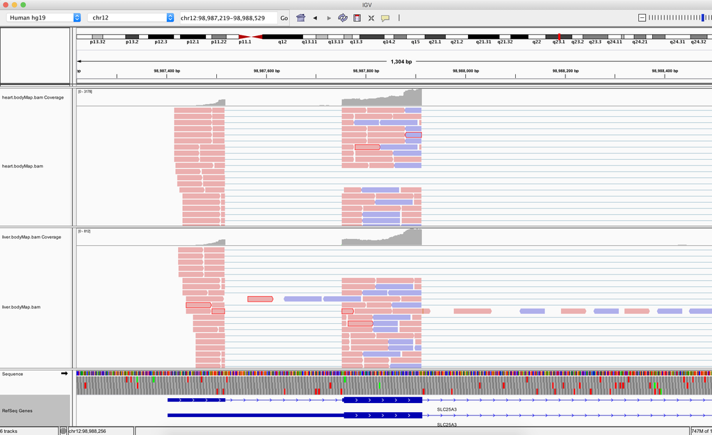

# SummariseOverlaps - A read only assigned to one feature

When using **summariseOverlaps()** function, a read can only be assigned to one feature.

This is important to note when counting features such as overlapping exons.

We will learn how to deal with counting across overlapping features in later sessions such as in RNA-seq.

# SummariseOverlaps for regions

To count non-overlapping regions, we can simply specify the path to our BAM file and a GRanges of regions to count over.

The returned object is a **RangedSummarizedExperiment** object.

```r
geneBody <- genes(TxDb.Hsapiens.UCSC.hg19.knownGene)
TSS <- promoters(geneBody,500,500)
myTSScounts <- summarizeOverlaps(TSS,"Heart.bam")
class(myTSScounts)
```

```
## [1] "RangedSummarizedExperiment"
## attr(,"package")
## [1] "SummarizedExperiment"
```

# SummarizedExperiment object

We can access the count matrix using the accessor function **assay()** with our **SummarizedExperiment** object.

Here we see total counts for SLC25A3 genes’ TSS region

```r
countMatrix <- assay(myTSScounts)
countMatrix["5250",]
```

```
##      Heart.bam
## 5250      4783
```

# SummariseOverlaps for gene models

For gene models, we may want to assign reads to each gene and so count all reads overlapping any exons within a gene.

We can count reads in meta-features such as genes using **GRangesLists**.

First we extract a GRangesList of exons for every gene.

```r
geneExons <- exonsBy(TxDb.Hsapiens.UCSC.hg19.knownGene,by="gene")
geneExons["5250"]
```

```
## GRangesList object of length 1:
## $5250
## GRanges object with 13 ranges and 2 metadata columns:
##        seqnames               ranges strand |   exon_id   exon_name
##           <Rle>            <IRanges>  <Rle> | <integer> <character>
##    [1]    chr12 [98987403, 98987518]      + |    164465        <NA>
##    [2]    chr12 [98987403, 98987913]      + |    164466        <NA>
##    [3]    chr12 [98987753, 98987913]      + |    164467        <NA>
##    [4]    chr12 [98987753, 98989626]      + |    164468        <NA>
##    [5]    chr12 [98987757, 98987913]      + |    164469        <NA>
##    ...      ...                  ...    ... .       ...         ...
##    [9]    chr12 [98991634, 98991813]      + |    164473        <NA>
##   [10]    chr12 [98992300, 98992481]      + |    164474        <NA>
##   [11]    chr12 [98993733, 98993905]      + |    164476        <NA>
##   [12]    chr12 [98994949, 98995059]      + |    164477        <NA>
##   [13]    chr12 [98995146, 98995778]      + |    164478        <NA>
##
## -------
## seqinfo: 93 sequences (1 circular) from hg19 genome
```

# SummariseOverlaps for gene models

And now we have a count of signal in exons for every gene.

```r
countMatrix <- assay(myGeneCounts)
countMatrix["5250",]
```

[output not shown]

```
##      Heart.bam
## 5250     65026
```

# SummarizeOverlaps for many files.

The **summarizeOverlaps()** function can count across multiple BAM files.

We can specify a vector of BAM file paths we wish to count from to **summarizeOverlaps()** function.

```r
allGeneCounts <- summarizeOverlaps(geneExons,
                                   c("Heart.bam","Liver.bam"))
```

# Low memory summarisation

Counting from BAM files, as with sorting, can be configured to trade of memory usage for speed.

i.e. less ram used but takes longer to count.

We can control the amount of memory used by creating a **BamFile** object prior to counting using the **BamFile()** function

```r
myBam <- BamFile("Heart.bam")
class(myBam)
```

```
## [1] "BamFile"
## attr(,"package")
## [1] "Rsamtools"
```

# Low memory summarisation

When counting multiple files we can use the **BamFileList()** function in a similar manner but this time we provide a vector of the two BAM file paths.

```r
myBam <- BamFileList(c("Heart.bam","Liver.bam"),
                     yieldSize = 1000)
allGeneCounts <- summarizeOverlaps(geneExons,myBam)
allGeneCounts
```

```
## class: RangedSummarizedExperiment
## dim: 23459 2
## metadata(0):
## assays(1): counts
## rownames(23459): 1 10 ... 9994 9997
## rowData names(0):
## colnames(2): Heart.bam Liver.bam
## colData names(0):
```

# Time for an exercise.